Regresar a la página principal

# Solución tercer punto

## Enunciado

En un reconocido centro de investigación se realiza un estudio para comparar varios tratamientos que al aplicarse previamente a los frijoles crudos reduzcan su tiempo de cocción. Estos tratamientos son a base de bicarbonato de sodio (NaHCO3) y cloruro de sodio o sal común (NaCl): El primer tratamiento es el tratamiento control, que consiste en no aplicar ningún tratamiento. El tratamiento T2 es el remojo en agua con bicarbonato de sodio, el T3 es en agua con sal común y el T4 es en agua con una combinación de ambos ingredientes en proporciones iguales. La variable respuesta es el tiempo de cocción en minutos. Los datos se muestran a continuación:

| CONTROL | T2 | T3 | T4 |
| --- | --- | --- | --- |
| 213 | 76 | 57 | 84 |
| 214 | 85 | 67 | 82 |
| 204 | 74 | 55 | 85 |
| 208 | 78 | 64 | 92 |
| 212 | 82 | 61 | 87 |
| 200 | 75 | 63 | 79 |
| 207 | 82 | 63 | 90 |

# Análisis exploratorio de los datos

Para eso, vamos a crear un vector con los datos de tiempos de cocción de los frijoles:

```r
library(tidyr)

# Creamos un data frame con los datos originales
datos <- data.frame(
  Control = c(213, 214, 204, 208, 212, 200, 207),
  T2 = c(76, 85, 74, 78, 82, 75, 82),
  T3 = c(57, 67, 55, 64, 61, 63, 63),
  T4 = c(84, 82, 85, 92, 87, 79, 90)
)

# Utilizamos pivot_longer para transformar la tabla
datos_longer <- pivot_longer(datos, cols = everything(), names_to = "Tratamiento", values_to = "Tiempo")

# Ver los primeros 6 filas del resultado
print(head(datos_longer))
```

```
## # A tibble: 6 × 2
##   Tratamiento Tiempo
##   <chr>        <dbl>
## 1 Control        213
## 2 T2              76
## 3 T3              57
## 4 T4              84
## 5 Control        214
## 6 T2              85
```

```r
#Resumen de los datos
summary(datos_longer)
```

```
##  Tratamiento            Tiempo
##  Length:28          Min.   : 55.00
##  Class :character   1st Qu.: 72.25
##  Mode  :character   Median : 82.00
##                     Mean   :108.54
##                     3rd Qu.:119.00
##                     Max.   :214.00
```

## Análisis gráfico

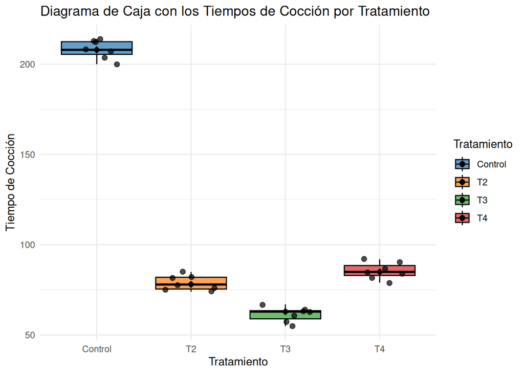

```r
library(ggplot2)

# Definiendo paleta de colores
mis_colores <- c("#1f77b4", "#ff7f0e", "#2ca02c", "#d62728")

# Diagrama de caja
ggplot(datos_longer, aes(x = Tratamiento, y = Tiempo, fill = Tratamiento)) +
  geom_boxplot(color = "black", alpha = 0.7, outlier.shape = 16, outlier.color = "red") +
  geom_point(position = position_jitter(width = 0.3), color = "black", alpha = 0.7, size = 2) +
  stat_summary(fun = median, geom = "point", color = "black", size = 3, shape = 18) +
  labs(title = "Diagrama de Caja con los Tiempos de Cocción por Tratamiento",
       x = "Tratamiento",
       y = "Tiempo de Cocción") +
  scale_fill_manual(values = mis_colores) +
  theme_minimal() +
  theme(legend.position = "right") +
  guides(fill = guide_legend(title = "Tratamiento", ncol = 1))
```

De acuerdo con el grafico de cajas al parecer, el tratamiento mas efectivo para reducir el periodo de coccion de los frijoles es el T3, donde se aplica agua con sal comun, el otro tratamiento T2, el uso de bicarbonato de sodio, y T4 en tercer lugar o mezcla de los anteriores y el menos efectivo es el agua normal T1 o tratamiento control.

```r
modelo1 <- aov(Tiempo ~ Tratamiento , data = datos_longer)
summary(modelo1)
```

```
##             Df Sum Sq Mean Sq F value Pr(>F)
## Tratamiento  3  95041   31680    1559 <2e-16 ***
## Residuals   24    488      20
## ---
## Signif. codes:  0 '***' 0.001 '**' 0.01 '*' 0.05 '.' 0.1 ' ' 1
```

Los resultados de la prueba ANOVA muestran que hay una diferencia significativa en los tiempos de cocción entre los diferentes tratamientos. Esto se evidencia por el valor extremadamente bajo del valor-p (Pr(>F)), que es prácticamente cero (<2e-16), indicando una fuerte evidencia en contra de la hipótesis nula de que no hay diferencias entre los grupos.

Además, el valor del estadístico F es bastante alto (1559), lo que indica una gran variabilidad entre los grupos en comparación con la variabilidad dentro de los grupos. Esto respalda aún más la conclusión de que los tratamientos tienen un efecto significativo en los tiempos de cocción.

Se puede concluir entonces que al menos un tratamiento tiene efecto significativo en los tiempos de cocción.

## Prueba post - ANOVA (Duncan)

Vamos a hacer la prueba Duncan para los tratamientos.

```r
library(agricolae)
# Realizar la prueba de Duncan
prueba_duncan <- duncan.test(modelo1, "Tratamiento", console = TRUE)
```

```
##
## Study: modelo1 ~ "Tratamiento"
##
## Duncan's new multiple range test
## for Tiempo
##
## Mean Square Error:  20.32143
##
## Tratamiento,  means
##
##            Tiempo      std r       se Min Max   Q25 Q50   Q75
## Control 208.28571 5.122313 7 1.703837 200 214 205.5 208 212.5
## T2       78.85714 4.180453 7 1.703837  74  85  75.5  78  82.0
## T3       61.42857 4.157609 7 1.703837  55  67  59.0  63  63.5
## T4       85.57143 4.503967 7 1.703837  79  92  83.0  85  88.5
##
## Alpha: 0.05 ; DF Error: 24
##
## Critical Range
##        2        3        4
## 4.973148 5.223301 5.383910
##
## Means with the same letter are not significantly different.
##
##            Tiempo groups
## Control 208.28571      a
## T4       85.57143      b
## T2       78.85714      c
## T3       61.42857      d
```